# Survival Analysis Final Project

Group 10

```r
library(readr)
library(tidyverse)
library(janitor)
library(ggcorrplot)
library(dplyr)
library(gtsummary)
library(tidyr)
library(ggplot2)
```

## EDA

### Load the dataset and clean column names

```r
file_path <- "Breast Cancer METABRIC.csv"

data <- read.csv(file_path, na.strings = "") %>%  # Treat blank strings as NA
  clean_names() %>%
  filter(cancer_type != "Breast Sarcoma") %>%  # only 3 patients are not Breast Cancer, exclude them
  rename(
    vital_status = patient_s_vital_status,
    three_gene_classifier_subtype = x3_gene_classifier_subtype
  ) %>%
  # Exclude patients with both overall_survival_months and overall_survival_status missing
  filter(!(is.na(overall_survival_months) & is.na(overall_survival_status)))

# View the cleaned data
head(data)
```

```
##   patient_id age_at_diagnosis type_of_breast_surgery   cancer_type
## 1    MB-0000            75.65             Mastectomy Breast Cancer
## 2    MB-0002            43.19      Breast Conserving Breast Cancer
## 3    MB-0005            48.87             Mastectomy Breast Cancer
## 4    MB-0006            47.68             Mastectomy Breast Cancer
## 5    MB-0008            76.97             Mastectomy Breast Cancer
## 6    MB-0010            78.77             Mastectomy Breast Cancer
##                        cancer_type_detailed cellularity chemotherapy
## 1          Breast Invasive Ductal Carcinoma        <NA>           No
## 2          Breast Invasive Ductal Carcinoma        High           No
## 3          Breast Invasive Ductal Carcinoma        High          Yes
## 4 Breast Mixed Ductal and Lobular Carcinoma    Moderate          Yes
## 5 Breast Mixed Ductal and Lobular Carcinoma        High          Yes
## 6          Breast Invasive Ductal Carcinoma    Moderate           No
##   pam50_claudin_low_subtype cohort er_status_measured_by_ihc er_status
```

[output cut: 55 more lines]

Our primary objective in this project is to investigate factors associated with overall survival (OS) in the METABRIC breast cancer cohort. Specifically, we define overall survival as the time from diagnosis to death from any cause, with overall_survival_months providing the follow-up time and overall_survival_status indicating whether the death event occurred.

For the survival analysis, both a valid survival time and an event indicator are required for each patient. In this dataset, some patients have overall_survival_months and overall_survival_status missing simultaneously, meaning that no follow-up or outcome information is available for these individuals. These cases are not censored observations but instead represent completely missing survival data. Therefore, we excluded patients with both overall_survival_months and overall_survival_status missing, so that the analysis dataset contains only patients with interpretable OS information for time-to-event modelling.

```r
dim(data)            # number of rows and columns
```

```
## [1] 1978   34
```

```r
colnames(data)       # check all variable names
```

```
##  [1] "patient_id"                     "age_at_diagnosis"
##  [3] "type_of_breast_surgery"         "cancer_type"
##  [5] "cancer_type_detailed"           "cellularity"
##  [7] "chemotherapy"                   "pam50_claudin_low_subtype"
##  [9] "cohort"                         "er_status_measured_by_ihc"
## [11] "er_status"                      "neoplasm_histologic_grade"
## [13] "her2_status_measured_by_snp6"   "her2_status"
## [15] "tumor_other_histologic_subtype" "hormone_therapy"
## [17] "inferred_menopausal_state"      "integrative_cluster"
## [19] "primary_tumor_laterality"       "lymph_nodes_examined_positive"
## [21] "mutation_count"                 "nottingham_prognostic_index"
## [23] "oncotree_code"                  "overall_survival_months"
## [25] "overall_survival_status"        "pr_status"
## [27] "radio_therapy"                  "relapse_free_status_months"
## [29] "relapse_free_status"            "sex"
## [31] "three_gene_classifier_subtype"  "tumor_size"
## [33] "tumor_stage"                    "vital_status"
```

### Visualization of Overall Survival (OS)

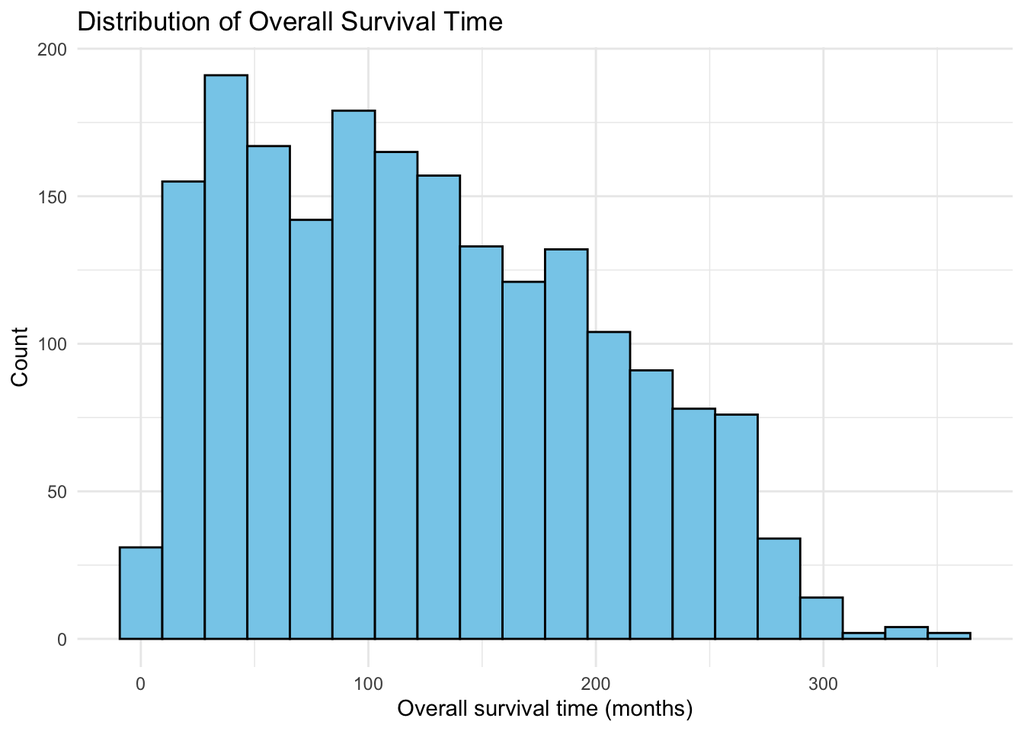

```r
ggplot(data, aes(x = overall_survival_months)) +
geom_histogram(bins = 20, color = "black", fill = "skyblue") +
labs(
title = "Distribution of Overall Survival Time",
x = "Overall survival time (months)",
y = "Count"
) +
theme_minimal()
```

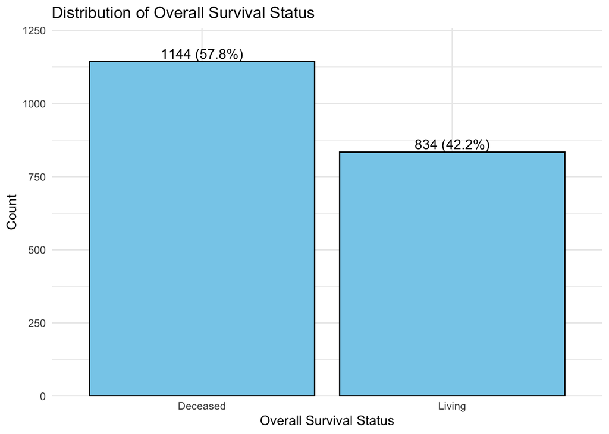

```r
ggplot(data, aes(x = factor(overall_survival_status))) +
  geom_bar(aes(y = ..count..), fill = "skyblue", color = "black") +  # Count bars
  geom_text(
    stat = "count",
    aes(label = paste0(..count.., " (", round(..count.. / sum(..count..) * 100, 1), "%)")),
    vjust = -0.3,      # move labels slightly above the bar
    color = "black",
    size = 4
  ) +
  scale_y_continuous(
    expand = expansion(mult = c(0, 0.1))  # add 10% headroom on top so labels are fully visible
  ) +
  labs(
    title = "Distribution of Overall Survival Status",
    x = "Overall Survival Status",
    y = "Count"
  ) +
  theme_minimal()
```

### Check for missing values:

```r
# Proportion and count of missing values per variable (only variables with missing values)
missing_summary <- data %>%
  summarise(across(everything(), ~ sum(is.na(.)))) %>%  # count missing values
  pivot_longer(
    cols = everything(),
    names_to = "variable",
    values_to = "missing_count"
  ) %>%
  mutate(
    prop_missing = missing_count / nrow(data)  # calculate proportion of missing values
  ) %>%     # keep only variables with any missing values
  arrange(desc(missing_count))       # sort by missing count (descending)

missing_summary
```

```
## # A tibble: 34 × 3
##    variable                       missing_count prop_missing
##    <chr>                                  <int>        <dbl>
##  1 tumor_stage                              514       0.260
##  2 three_gene_classifier_subtype            216       0.109
##  3 mutation_count                           119       0.0602
##  4 primary_tumor_laterality                 110       0.0556
##  5 neoplasm_histologic_grade                 85       0.0430
##  6 lymph_nodes_examined_positive             74       0.0374
##  7 cellularity                               63       0.0319
##  8 tumor_other_histologic_subtype            42       0.0212
##  9 er_status_measured_by_ihc                 40       0.0202
## 10 type_of_breast_surgery                    25       0.0126
## # ℹ 24 more rows
```

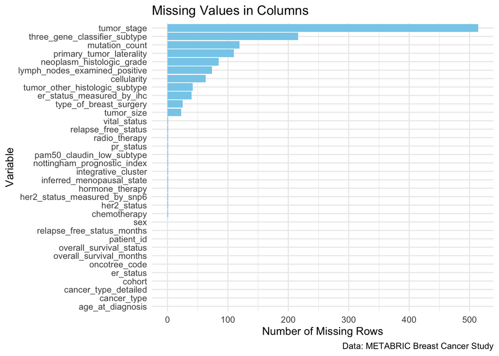

```r
# Plot missing values per variable (count)
ggplot(missing_summary, aes(x = reorder(variable, missing_count), y = missing_count)) +
  geom_bar(stat = "identity", fill = "skyblue") +
  labs(
    title = "Missing Values in Columns",
    x = "Variable",
    y = "Number of Missing Rows",
    caption = "Data: METABRIC Breast Cancer Study"
  ) +
  theme_minimal() +
  coord_flip()  # Flip the chart for better readability
```

### Define continuous and categorical variables manually:

#### Continuous variables:

```r
continuous_vars <- c(
  "age_at_diagnosis",
  "tumor_size",
  "lymph_nodes_examined_positive",
  "mutation_count",
  "overall_survival_months",
  "relapse_free_status_months"
)

continuous_vars
```

```
## [1] "age_at_diagnosis"              "tumor_size"
## [3] "lymph_nodes_examined_positive" "mutation_count"
## [5] "overall_survival_months"       "relapse_free_status_months"
```

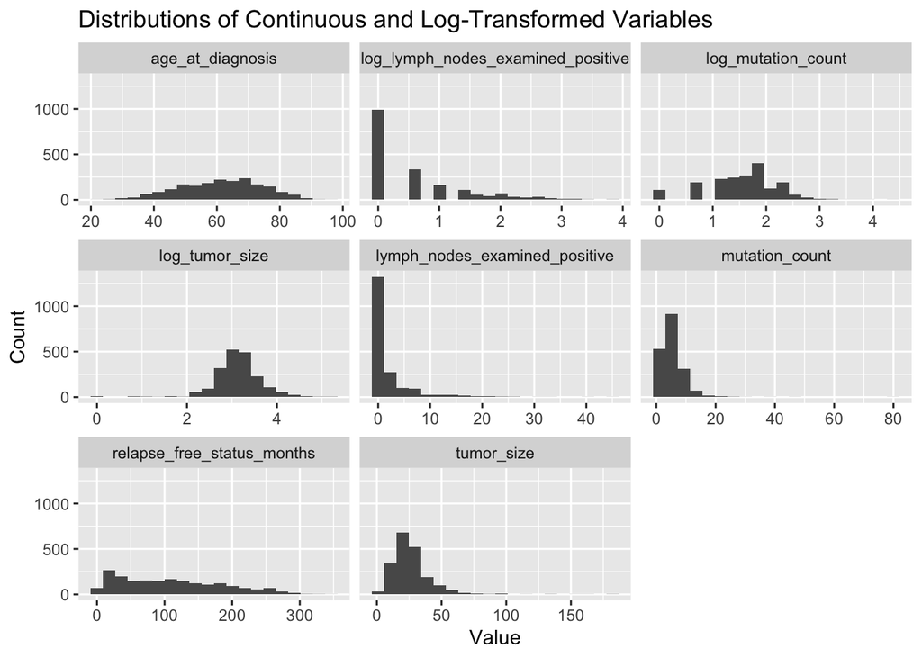

```r
data_plot <- data %>%
  mutate(
    log_tumor_size = log(tumor_size),
    log_mutation_count = log(mutation_count),
    log_lymph_nodes_examined_positive = log(lymph_nodes_examined_positive+1)
  )

# variables you want to plot (original + new logs)
vars_to_plot <- c(
  setdiff(continuous_vars, "overall_survival_months"),    # original ones
  "log_tumor_size",
  "log_mutation_count",
  "log_lymph_nodes_examined_positive"
)

# ---- PLOT ------------------------------------------------------------------

data_plot %>%
  select(all_of(vars_to_plot)) %>%
  pivot_longer(
    cols = everything(),
    names_to = "variable",
    values_to = "value"
  ) %>%
  ggplot(aes(x = value)) +
  geom_histogram(bins = 20) +
  facet_wrap(~ variable, scales = "free_x") +
  labs(
    title = "Distributions of Continuous and Log-Transformed Variables",
    x = "Value",
    y = "Count"
  )
```

#### Categorical variables:

```r
# Treat other variables as categorical for EDA, but exclude patient_id
categorical_vars <- setdiff(names(data), c(continuous_vars, "patient_id"))
```

```r
# Frequency and proportion for each categorical variable (excluding overall_survival_status)
for (var in setdiff(categorical_vars, "overall_survival_status")) {
  cat("\n\n==============================\n")
  cat("Variable:", var, "\n")

  tmp <- data %>%
    count(.data[[var]]) %>%                 # count each level
    mutate(prop = n / sum(n)) %>%           # proportion within the variable
    arrange(desc(n))                        # sort by frequency

  print(tmp)                 # print all rows for this variable
}
```

```
##
##
## ==============================
## Variable: type_of_breast_surgery
##   type_of_breast_surgery    n       prop
## 1             Mastectomy 1169 0.59100101
## 2      Breast Conserving  784 0.39635996
## 3                   <NA>   25 0.01263903
##
##
## ==============================
## Variable: cancer_type
##     cancer_type    n prop
## 1 Breast Cancer 1978    1
##
```

[output cut: 546 more lines]

sex and cancer_type have only a single category (Female and Breast Cancer) in this dataset, making them uninformative for the survival analysis model, as they do not provide any variation in the data.

```r
# Remove 'sex' and 'cancer_type' from categorical_vars
categorical_vars <- setdiff(categorical_vars, c("sex", "cancer_type"))

# Print updated categorical_vars
categorical_vars
```

```
##  [1] "type_of_breast_surgery"         "cancer_type_detailed"
##  [3] "cellularity"                    "chemotherapy"
##  [5] "pam50_claudin_low_subtype"      "cohort"
##  [7] "er_status_measured_by_ihc"      "er_status"
##  [9] "neoplasm_histologic_grade"      "her2_status_measured_by_snp6"
## [11] "her2_status"                    "tumor_other_histologic_subtype"
## [13] "hormone_therapy"                "inferred_menopausal_state"
## [15] "integrative_cluster"            "primary_tumor_laterality"
## [17] "nottingham_prognostic_index"    "oncotree_code"
## [19] "overall_survival_status"        "pr_status"
## [21] "radio_therapy"                  "relapse_free_status"
## [23] "three_gene_classifier_subtype"  "tumor_stage"
## [25] "vital_status"
```

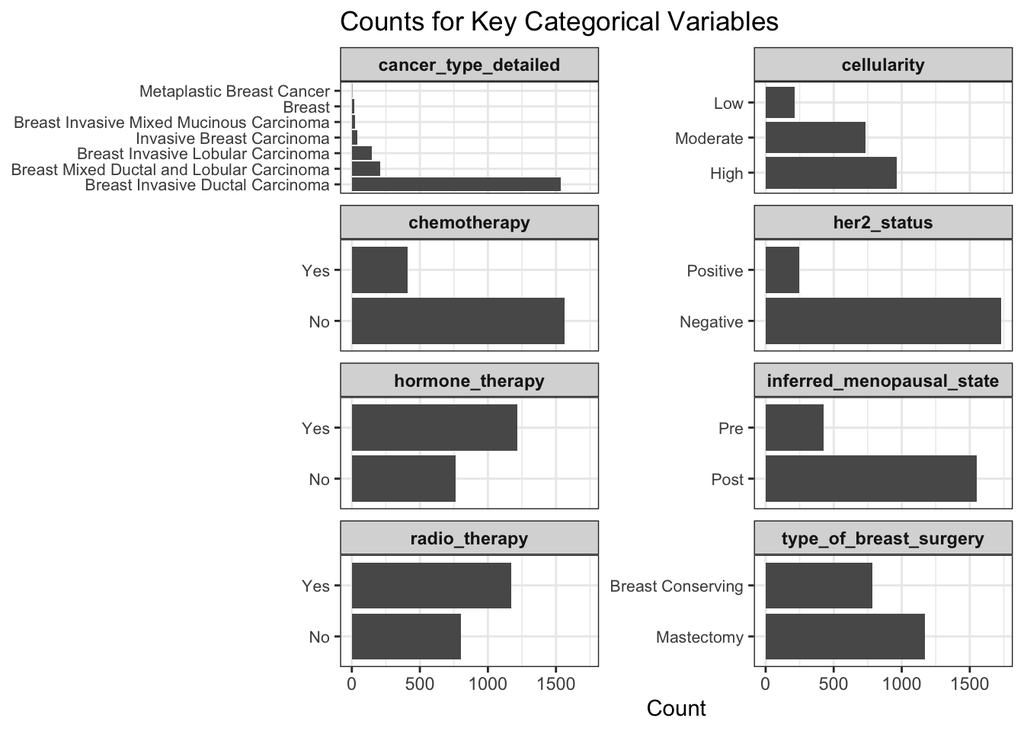

```r
cats_for_plot <- c(
  "type_of_breast_surgery",
  "cancer_type_detailed",
  "cellularity",
  "chemotherapy",
  "her2_status",
  "hormone_therapy",
  "radio_therapy",
  "inferred_menopausal_state"
)

cat_long <- data %>%
  select(all_of(cats_for_plot)) %>%
  pivot_longer(
    cols = everything(),
    names_to  = "variable",
    values_to = "category"
  ) %>%
  drop_na(category) %>%
  # order levels within each variable by frequency
  group_by(variable) %>%
  mutate(category = fct_infreq(category)) %>%
  ungroup()

ggplot(cat_long, aes(x = category)) +
  geom_bar() +
  coord_flip() +  # make bars horizontal so labels are readable
  facet_wrap(~ variable, scales = "free_y", ncol = 2) +
  labs(
    title = "Counts for Key Categorical Variables",
    x = NULL,
    y = "Count"
  ) +
  theme_bw() +
  theme(
    axis.text.y = element_text(size = 8),
    strip.text  = element_text(face = "bold")
  )
```

### Correlation analysis:

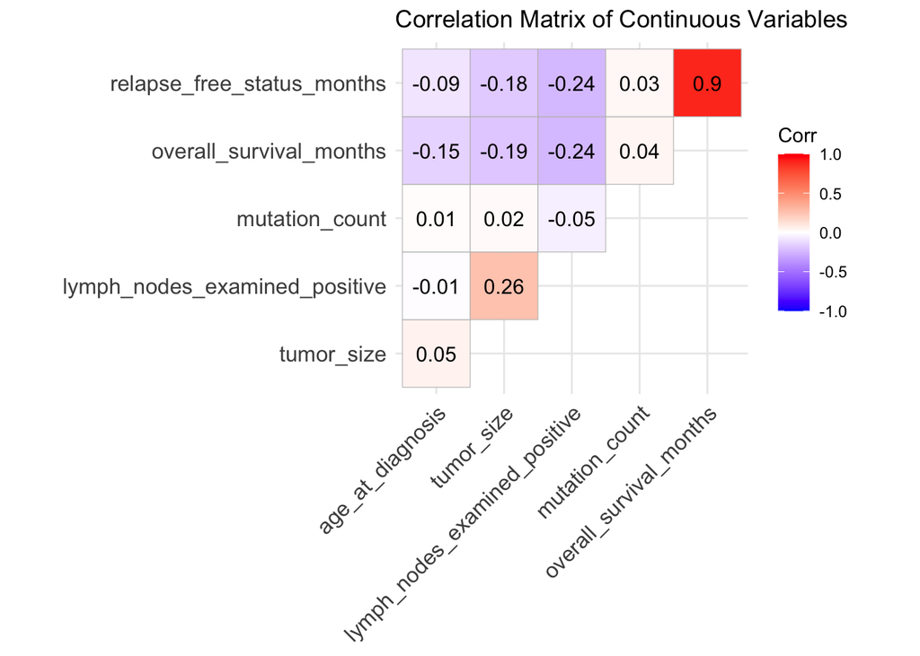

```r
# Calculate correlation matrix for continuous variables
cor_matrix <- data %>%
  select(all_of(continuous_vars)) %>%
  cor(use = "pairwise.complete.obs")  # handle NA values by pairwise complete observation

ggcorrplot(cor_matrix,
           type = "upper",        # Show only the lower triangle of the matrix
           lab = TRUE,            # Display correlation values
           colors = c("blue", "white", "red"),  # Color gradient
           title = "Correlation Matrix of Continuous Variables")
```

If we are conducting survival analysis with overall_survival_status as the event indicator, we should exclude relapse_free_status_months as a predictor in the model, as it is strongly correlated with overall_survival_months. Including both would lead to multicollinearity, where these two variables would essentially provide redundant information, making it difficult to assess their independent effects on survival. Therefore, we should choose overall_survival_months as the time variable, as it directly represents the total survival time and includes all relevant information related to the occurrence of the event.

```r
# Remove 'relapse_free_status_months' from continuous_vars
continuous_vars <- setdiff(continuous_vars, "relapse_free_status_months")
```

```r
for (var in categorical_vars) {
  # Create a contingency table for each variable and survival status
  contingency_table <- table(data[[var]], data$overall_survival_status)
  print(contingency_table)
}
```

```
##
##                     Deceased Living
##   Breast Conserving      368    416
##   Mastectomy             759    410
##
##                                             Deceased Living
##   Breast                                           5     12
##   Breast Invasive Ductal Carcinoma               891    646
##   Breast Invasive Lobular Carcinoma               86     60
##   Breast Invasive Mixed Mucinous Carcinoma        10     13
##   Breast Mixed Ductal and Lobular Carcinoma      132     79
##   Invasive Breast Carcinoma                       18     24
##   Metaplastic Breast Cancer                        2      0
##
##            Deceased Living
##   High          562    402
##   Low           116     99
##   Moderate      436    300
##
##       Deceased Living
##   No       920    645
##   Yes      223    189
##
##               Deceased Living
##   Basal            115     94
##   claudin-low       94    121
##   Her2             157     67
##   LumA             378    322
##   LumB             315    160
##   NC                 5      1
##   Normal            79     69
##
##     Deceased Living
##   1      227    292
##   2      149    139
##   3      529    234
##   4      124    114
##   5      115     55
##
##            Deceased Living
```

[output cut: 406 more lines]

```
##   ER+/HER2- High Prolif      400    217
##   ER+/HER2- Low Prolif       329    311
##   HER2+                      121     77
##
##     Deceased Living
##   0        2      9
##   1      228    272
##   2      497    328
##   3       87     31
##   4        9      1
##
##                        Deceased Living
##   Died of Disease           646      0
##   Died of Other Causes      497      0
##   Living                      0    834
```

Since “vital_status” variable is already directly related to the outcome of survival and is a proxy for the status of the patient, it is unnecessary to include it in the model. This variable is highly correlated with survival, and adding it could lead to perfect prediction of the outcome or multicollinearity.

```r
# Exclude "vital_status","cohort","relapse_free_status" in categorical variables
categorical_vars <- setdiff(categorical_vars, c("vital_status","cohort","relapse_free_status"))
categorical_vars
```

```
##  [1] "type_of_breast_surgery"         "cancer_type_detailed"
##  [3] "cellularity"                    "chemotherapy"
##  [5] "pam50_claudin_low_subtype"      "er_status_measured_by_ihc"
##  [7] "er_status"                      "neoplasm_histologic_grade"
##  [9] "her2_status_measured_by_snp6"   "her2_status"
## [11] "tumor_other_histologic_subtype" "hormone_therapy"
## [13] "inferred_menopausal_state"      "integrative_cluster"
## [15] "primary_tumor_laterality"       "nottingham_prognostic_index"
## [17] "oncotree_code"                  "overall_survival_status"
## [19] "pr_status"                      "radio_therapy"
## [21] "three_gene_classifier_subtype"  "tumor_stage"
```

### Final dataset after variable selection

```r
# Filter the data by including only the selected variables from both categorical_vars and continuous_vars
selected_vars <- c(categorical_vars, continuous_vars)

# Create a new dataset with only the selected variables
filtered_data <- data %>%
  select(all_of(selected_vars))

# View the filtered dataset
head(filtered_data)
```

```
##   type_of_breast_surgery                      cancer_type_detailed cellularity
## 1             Mastectomy          Breast Invasive Ductal Carcinoma        <NA>
## 2      Breast Conserving          Breast Invasive Ductal Carcinoma        High
## 3             Mastectomy          Breast Invasive Ductal Carcinoma        High
## 4             Mastectomy Breast Mixed Ductal and Lobular Carcinoma    Moderate
## 5             Mastectomy Breast Mixed Ductal and Lobular Carcinoma        High
## 6             Mastectomy          Breast Invasive Ductal Carcinoma    Moderate
##   chemotherapy pam50_claudin_low_subtype er_status_measured_by_ihc er_status
## 1           No               claudin-low                   Positve  Positive
## 2           No                      LumA                   Positve  Positive
## 3          Yes                      LumB                   Positve  Positive
## 4          Yes                      LumB                   Positve  Positive
## 5          Yes                      LumB                   Positve  Positive
## 6           No                      LumB                   Positve  Positive
##   neoplasm_histologic_grade her2_status_measured_by_snp6 her2_status
```

[output cut: 41 more lines]

### Overview of demographic and baseline variables (Table 1)

```r
filtered_data <- filtered_data |>
  mutate(overall_survival_status = factor(overall_survival_status))

vars_for_table1 <- c(
  "age_at_diagnosis",
  "her2_status",
  "tumor_size",
  "lymph_nodes_examined_positive",
  "mutation_count",
  "nottingham_prognostic_index",
  "type_of_breast_surgery",
  "cancer_type_detailed",
  "pam50_claudin_low_subtype",
  "neoplasm_histologic_grade",
  "tumor_other_histologic_subtype",
  "inferred_menopausal_state",
  "integrative_cluster",
  "radio_therapy",
  "three_gene_classifier_subtype",
  "tumor_stage"
)

continuous_vars <- c(
  "age_at_diagnosis",
  "tumor_size",
  "lymph_nodes_examined_positive",
  "mutation_count",
  "nottingham_prognostic_index"
)
categorical_vars <- setdiff(vars_for_table1, continuous_vars)

pvalue_fmt <- function(x) {
  ifelse(x < 0.001, "<0.001", formatC(x, format = "f", digits = 3))
}

table1 <-
  data |>
  dplyr::select(all_of(c("overall_survival_status", vars_for_table1))) |>
  tbl_summary(
    by = overall_survival_status,
    type = list(
      all_of(continuous_vars)  ~ "continuous2",
      all_of(categorical_vars) ~ "categorical"
    ),
    statistic = list(
      all_of(continuous_vars) ~ "{mean} ({sd})",
      all_categorical()       ~ "{n} ({p}%)"
    ),
    missing = "no"   # <--- do NOT create 'Unknown' rows
  ) |>
  add_n() |>
  add_p(
    test = list(
      all_of(continuous_vars)  ~ "t.test",
      all_categorical()        ~ "chisq.test"
    ),
    pvalue_fun = pvalue_fmt
  ) |>
  modify_caption("**Table 1. Baseline characteristics by overall survival status**") |>
  bold_labels()
```

[output not shown]

```r
table1
```

**Table 1. Baseline characteristics by overall survival status**

| **Characteristic** | **N** | **Deceased** N = 1,144<sup>1</sup> | **Living** N = 834<sup>1</sup> | **p-value**<sup>2</sup> |
| --- | --- | --- | --- | --- |
| age_at_diagnosis | 1,978 |  |  | <0.001 |
| Mean (SD) |  | 64 (13) | 57 (11) |  |
| her2_status | 1,977 |  |  | 0.107 |
| Negative |  | 988 (86%) | 742 (89%) |  |
| Positive |  | 155 (14%) | 92 (11%) |  |
| tumor_size | 1,955 |  |  | <0.001 |
| Mean (SD) |  | 28 (16) | 23 (13) |  |
| lymph_nodes_examined_positive | 1,904 |  |  | <0.001 |
| Mean (SD) |  | 2.6 (4.8) | 1.2 (2.7) |  |
| mutation_count | 1,859 |  |  | <0.001 |
| Mean (SD) |  | 6.0 (4.5) | 5.3 (3.3) |  |
| nottingham_prognostic_index | 1,977 |  |  | <0.001 |
| Mean (SD) |  | 4.15 (1.20) | 3.83 (1.08) |  |
| type_of_breast_surgery | 1,953 |  |  | <0.001 |
| Breast Conserving |  | 368 (33%) | 416 (50%) |  |
| Mastectomy |  | 759 (67%) | 410 (50%) |  |
| cancer_type_detailed | 1,978 |  |  | 0.021 |
| Breast |  | 5 (0.4%) | 12 (1.4%) |  |
| Breast Invasive Ductal Carcinoma |  | 891 (78%) | 646 (77%) |  |
| Breast Invasive Lobular Carcinoma |  | 86 (7.5%) | 60 (7.2%) |  |
| Breast Invasive Mixed Mucinous Carcinoma |  | 10 (0.9%) | 13 (1.6%) |  |
| Breast Mixed Ductal and Lobular Carcinoma |  | 132 (12%) | 79 (9.5%) |  |
| Invasive Breast Carcinoma |  | 18 (1.6%) | 24 (2.9%) |  |
| Metaplastic Breast Cancer |  | 2 (0.2%) | 0 (0%) |  |
| pam50_claudin_low_subtype | 1,977 |  |  | <0.001 |
| Basal |  | 115 (10%) | 94 (11%) |  |
| claudin-low |  | 94 (8.2%) | 121 (15%) |  |
| Her2 |  | 157 (14%) | 67 (8.0%) |  |
| LumA |  | 378 (33%) | 322 (39%) |  |
| LumB |  | 315 (28%) | 160 (19%) |  |
| NC |  | 5 (0.4%) | 1 (0.1%) |  |
| Normal |  | 79 (6.9%) | 69 (8.3%) |  |
| neoplasm_histologic_grade | 1,893 |  |  | <0.001 |
| 1 |  | 76 (7.0%) | 93 (12%) |  |
| 2 |  | 432 (40%) | 339 (42%) |  |
| 3 |  | 579 (53%) | 374 (46%) |  |
| tumor_other_histologic_subtype | 1,936 |  |  | 0.010 |
| Ductal/NST |  | 871 (77%) | 620 (77%) |  |
| Lobular |  | 86 (7.6%) | 60 (7.4%) |  |
| Medullary |  | 14 (1.2%) | 11 (1.4%) |  |
| Metaplastic |  | 2 (0.2%) | 0 (0%) |  |
| Mixed |  | 132 (12%) | 79 (9.8%) |  |
| Mucinous |  | 10 (0.9%) | 13 (1.6%) |  |
| Other |  | 5 (0.4%) | 12 (1.5%) |  |
| Tubular/ cribriform |  | 6 (0.5%) | 15 (1.9%) |  |
| inferred_menopausal_state | 1,977 |  |  | <0.001 |
| Post |  | 966 (85%) | 587 (70%) |  |
| Pre |  | 177 (15%) | 247 (30%) |  |
| integrative_cluster | 1,977 |  |  | <0.001 |
| 1 |  | 80 (7.0%) | 59 (7.1%) |  |
| 10 |  | 107 (9.4%) | 118 (14%) |  |
| 2 |  | 52 (4.5%) | 20 (2.4%) |  |
| 3 |  | 151 (13%) | 139 (17%) |  |
| 4ER- |  | 44 (3.8%) | 38 (4.6%) |  |
| 4ER+ |  | 130 (11%) | 129 (15%) |  |
| 5 |  | 130 (11%) | 60 (7.2%) |  |
| 6 |  | 59 (5.2%) | 26 (3.1%) |  |
| 7 |  | 113 (9.9%) | 77 (9.2%) |  |
| 8 |  | 179 (16%) | 120 (14%) |  |
| 9 |  | 98 (8.6%) | 48 (5.8%) |  |
| radio_therapy | 1,977 |  |  | <0.001 |
| No |  | 514 (45%) | 290 (35%) |  |
| Yes |  | 629 (55%) | 544 (65%) |  |
| three_gene_classifier_subtype | 1,762 |  |  | <0.001 |
| ER-/HER2- |  | 153 (15%) | 154 (20%) |  |
| ER+/HER2- High Prolif |  | 400 (40%) | 217 (29%) |  |
| ER+/HER2- Low Prolif |  | 329 (33%) | 311 (41%) |  |
| HER2+ |  | 121 (12%) | 77 (10%) |  |
| tumor_stage | 1,464 |  |  | <0.001 |
| 0 |  | 2 (0.2%) | 9 (1.4%) |  |
| 1 |  | 228 (28%) | 272 (42%) |  |
| 2 |  | 497 (60%) | 328 (51%) |  |
| 3 |  | 87 (11%) | 31 (4.8%) |  |
| 4 |  | 9 (1.1%) | 1 (0.2%) |  |

<sup>1</sup> n (%)  
<sup>2</sup> Welch Two Sample t-test; Pearson’s Chi-squared test

### Multivariable Cox Model

```r
library(survival)
library(broom)

final_inter_mod <- coxph(
  Surv(
    overall_survival_months,
    overall_survival_status == "Deceased"   # event indicator
  ) ~
    age_at_diagnosis +
    tumor_size +
    lymph_nodes_examined_positive +
    nottingham_prognostic_index +
    radio_therapy +
    inferred_menopausal_state +
    tumor_stage +
    three_gene_classifier_subtype +
    type_of_breast_surgery +
    cancer_type_detailed +
    pam50_claudin_low_subtype +
    tumor_other_histologic_subtype +
    integrative_cluster +
    mutation_count +
    radio_therapy:tumor_size, # treatment × tumor size interaction
  data = filtered_data
)
summary(final_inter_mod)
```

```
## Call:
## coxph(formula = Surv(overall_survival_months, overall_survival_status ==
##     "Deceased") ~ age_at_diagnosis + tumor_size + lymph_nodes_examined_positive +
##     nottingham_prognostic_index + radio_therapy + inferred_menopausal_state +
##     tumor_stage + three_gene_classifier_subtype + type_of_breast_surgery +
##     cancer_type_detailed + pam50_claudin_low_subtype + tumor_other_histologic_subtype +
##     integrative_cluster + mutation_count + radio_therapy:tumor_size,
##     data = filtered_data)
##
##   n= 1186, number of events= 665
##    (792 observations deleted due to missingness)
##
##                                                                     coef
## age_at_diagnosis                                               4.915e-02
## tumor_size                                                     1.362e-02
## lymph_nodes_examined_positive                                  5.022e-02
## nottingham_prognostic_index                                    1.176e-01
## radio_therapyYes                                              -2.313e-02
## inferred_menopausal_statePre                                   5.351e-01
## tumor_stage                                                    8.522e-02
## three_gene_classifier_subtypeER+/HER2- High Prolif            -1.273e-01
## three_gene_classifier_subtypeER+/HER2- Low Prolif             -2.845e-01
## three_gene_classifier_subtypeHER2+                            -4.093e-01
## type_of_breast_surgeryMastectomy                               1.047e-01
## cancer_type_detailedBreast Invasive Ductal Carcinoma           1.518e+01
## cancer_type_detailedBreast Invasive Lobular Carcinoma          1.495e+01
## cancer_type_detailedBreast Invasive Mixed Mucinous Carcinoma   1.454e+01
## cancer_type_detailedBreast Mixed Ductal and Lobular Carcinoma  1.521e+01
## pam50_claudin_low_subtypeclaudin-low                          -2.838e-01
## pam50_claudin_low_subtypeHer2                                  8.155e-02
## pam50_claudin_low_subtypeLumA                                 -2.305e-01
## pam50_claudin_low_subtypeLumB                                 -2.020e-01
## pam50_claudin_low_subtypeNC                                   -9.304e-01
## pam50_claudin_low_subtypeNormal                                1.491e-01
## tumor_other_histologic_subtypeLobular                                 NA
## tumor_other_histologic_subtypeMedullary                        3.351e-01
## tumor_other_histologic_subtypeMixed                                   NA
## tumor_other_histologic_subtypeMucinous                                NA
## tumor_other_histologic_subtypeOther                                   NA
## tumor_other_histologic_subtypeTubular/ cribriform             -5.608e-01
```

[output cut: 285 more lines]

```
## integrative_cluster3                                              1.513
## integrative_cluster4ER-                                           1.539
## integrative_cluster4ER+                                           1.314
## integrative_cluster5                                              3.206
## integrative_cluster6                                              1.469
## integrative_cluster7                                              1.400
## integrative_cluster8                                              1.419
## integrative_cluster9                                              1.425
## mutation_count                                                    1.022
## tumor_size:radio_therapyYes                                       1.005
##
## Concordance= 0.693  (se = 0.011 )
## Likelihood ratio test= 330  on 35 df,   p=<2e-16
## Wald test            = 339.5  on 35 df,   p=<2e-16
## Score (logrank) test = 379  on 35 df,   p=<2e-16
```

```r
cox_tidy <- broom::tidy(
  final_inter_mod,
  exponentiate = TRUE,
  conf.int     = TRUE
)

cox_tidy
```

```
## # A tibble: 39 × 7
##    term                 estimate std.error statistic  p.value conf.low conf.high
##    <chr>                   <dbl>     <dbl>     <dbl>    <dbl>    <dbl>     <dbl>
##  1 age_at_diagnosis        1.05    0.00488    10.1   7.56e-24    1.04       1.06
##  2 tumor_size              1.01    0.00578     2.36  1.85e- 2    1.00       1.03
##  3 lymph_nodes_examine…    1.05    0.0119      4.23  2.35e- 5    1.03       1.08
##  4 nottingham_prognost…    1.12    0.0523      2.25  2.47e- 2    1.02       1.25
##  5 radio_therapyYes        0.977   0.199      -0.116 9.07e- 1    0.662      1.44
##  6 inferred_menopausal…    1.71    0.157       3.41  6.47e- 4    1.26       2.32
##  7 tumor_stage             1.09    0.0841      1.01  3.11e- 1    0.923      1.28
##  8 three_gene_classifi…    0.880   0.214      -0.596 5.51e- 1    0.579      1.34
##  9 three_gene_classifi…    0.752   0.219      -1.30  1.94e- 1    0.490      1.16
## 10 three_gene_classifi…    0.664   0.292      -1.40  1.61e- 1    0.375      1.18
## # ℹ 29 more rows
```

The multivariable Cox proportional hazards model evaluates how demographic, tumor, and treatment characteristics jointly affect overall survival among METABRIC breast cancer patients. After adjustment for all covariates, traditional prognostic factors such as older age at diagnosis, larger tumor size, a higher number of positive lymph nodes, and a higher Nottingham prognostic index generally show associations compatible with increased hazard of death, indicating worse survival as these measures of disease burden increase.

Tumor-related categorical variables, including tumor stage, three_gene_classifier_subtype (ER/HER2 profile), pam50_claudin_low_subtype, tumor_other_histologic_subtype, cancer_type_detailed, and integrative_cluster, capture biologic and histologic differences between tumors and contribute additional information on risk. Treatment variables such as radio_therapy, along with menopausal status and type_of_breast_surgery, help describe differences in management patterns and their impact on survival. The inclusion of a radio_therapy × tumor_size interaction allows the association between tumor size and mortality risk to differ between patients who did and did not receive radiotherapy.

Hazard ratios from this model represent the multiplicative change in the instantaneous risk of death associated with each covariate, holding all others constant. The directions of effect are broadly consistent with clinical expectations; however, these interpretations rely on the proportional hazards assumption, which is examined in the next section.

### Proportional hazards (PH) diagnostics

```r
# Residual diagnostics
par(mfrow = c(2, 2))

plot(
  resid(final_inter_mod, type = "martingale"),
  main = "Martingale Residuals vs Linear Predictor",
  ylab = "Martingale Residuals"
)
abline(h = 0, lty = 2)

plot(
  resid(final_inter_mod, type = "deviance"),
  main = "Deviance Residuals vs Linear Predictor",
  ylab = "Deviance Residuals"
)
abline(h = 0, lty = 2)

# Schoenfeld residual PH test
ph_test <- cox.zph(final_inter_mod)
ph_test
```

```
##                                   chisq df       p
## age_at_diagnosis                56.2469  1 6.4e-14
## tumor_size                       2.6581  1 0.10303
## lymph_nodes_examined_positive    4.1983  1 0.04046
## nottingham_prognostic_index     36.1266  1 1.8e-09
## radio_therapy                    0.8096  1 0.36825
## inferred_menopausal_state       26.2766  1 3.0e-07
## tumor_stage                     10.9739  1 0.00092
## three_gene_classifier_subtype   48.0542  3 2.1e-10
## type_of_breast_surgery           0.0169  1 0.89668
## cancer_type_detailed             8.7272  4 0.06829
## pam50_claudin_low_subtype       54.7164  6 5.3e-10
## tumor_other_histologic_subtype   1.0153  2 0.60190
## integrative_cluster             73.8193 10 8.1e-12
## mutation_count                   0.1202  1 0.72884
## tumor_size:radio_therapy         1.2559  1 0.26242
## GLOBAL                         139.5229 35 2.0e-14
```

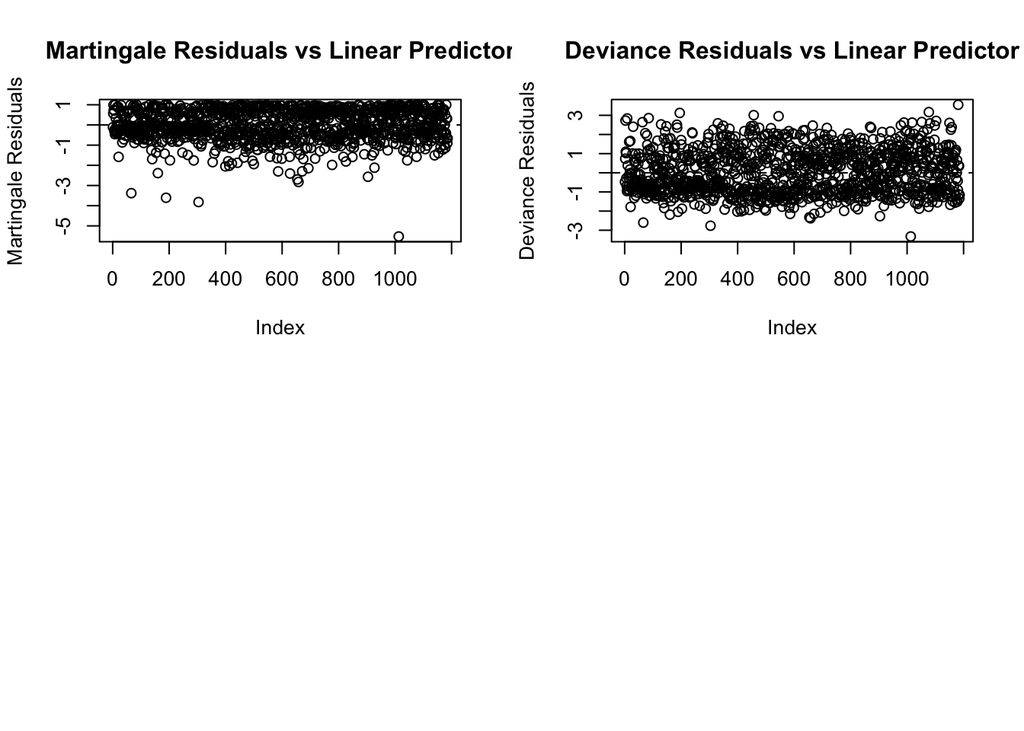

```r
# Schoenfeld residual plots
par(mfrow = c(2, 2))
```

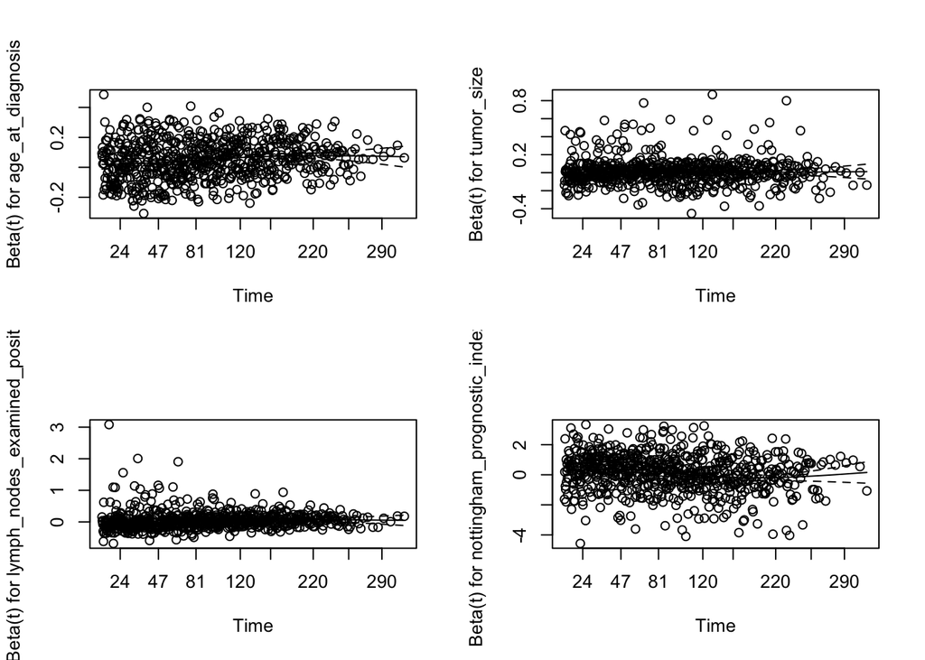

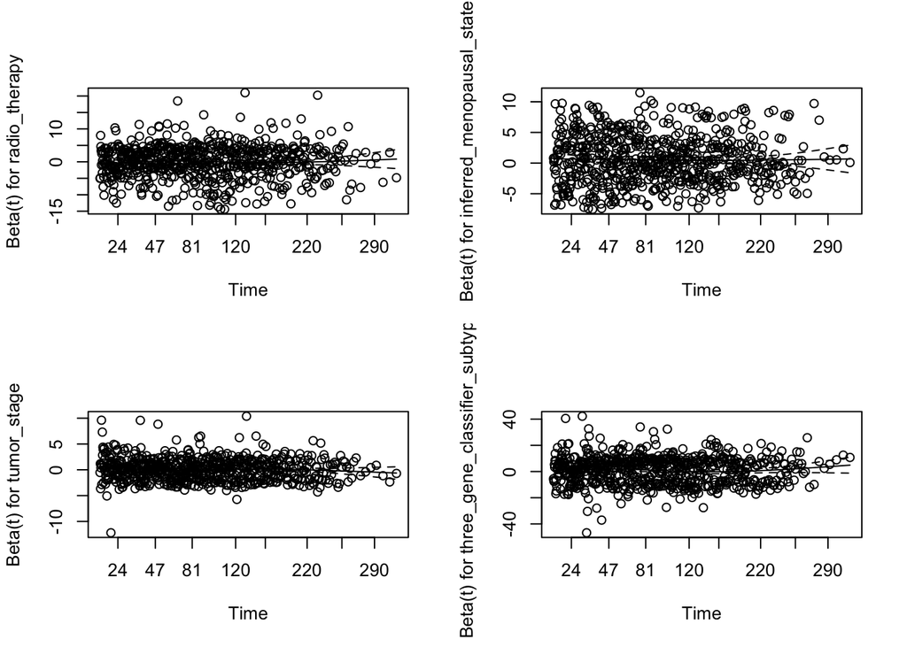

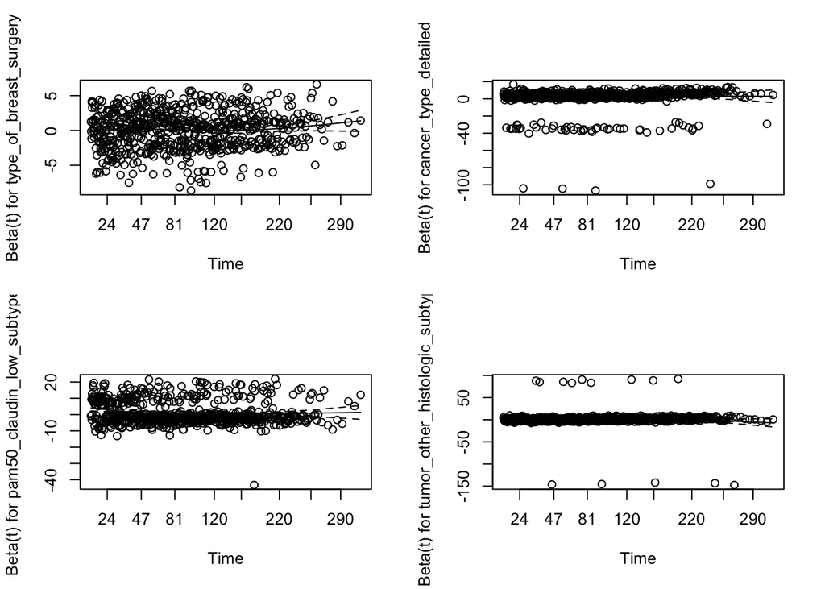

```r
plot(ph_test)
```

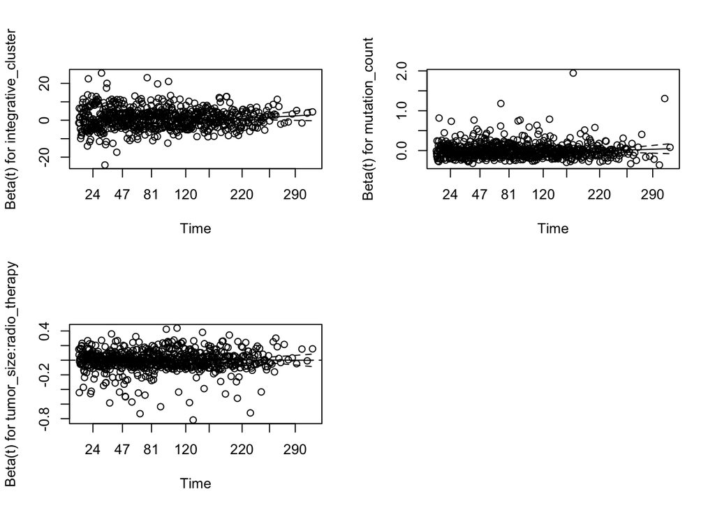

```r
abline(h = 0, lty = 2)
par(mfrow = c(1, 1))
```

Martingale and deviance residual plots do not reveal severe global model misfit, although a small number of influential observations and mild departures from perfect linearity are apparent. These diagnostics mainly suggest that the overall functional form of the model is reasonable but not flawless.

Because the proportional hazards assumption is a key requirement of the Cox model, these findings imply that hazard ratios should be interpreted with some caution. To investigate robustness under an alternative modeling framework that does not require proportional hazards, we fit accelerated failure time (AFT) models as a sensitivity analysis.

### AFT sensitivity analysis

```r
aft_weibull <- survreg(
  Surv(
    overall_survival_months,
    overall_survival_status == "Deceased"
  ) ~
    age_at_diagnosis +
    tumor_size +
    lymph_nodes_examined_positive +
    nottingham_prognostic_index +
    radio_therapy +
    inferred_menopausal_state +
    tumor_stage +
    three_gene_classifier_subtype +
    type_of_breast_surgery +
    cancer_type_detailed +
    pam50_claudin_low_subtype +
    tumor_other_histologic_subtype +
    integrative_cluster +
    mutation_count +
    log(tumor_size):radio_therapy +
    age_at_diagnosis:radio_therapy,
  data = filtered_data,
  dist = "weibull"
)

# Compare alternative distributions
aft_lognormal   <- update(aft_weibull, dist = "lognormal")
aft_loglogistic <- update(aft_weibull, dist = "loglogistic")

AIC(aft_lognormal)
```

```
## [1] 8307.446
```

```r
AIC(aft_weibull)
```

```
## [1] 8260.395
```

```r
AIC(aft_loglogistic)
```

```
## [1] 8266.172
```

```r
# Extract time ratios with confidence intervals for Weibull model
aft_ci <- exp(confint(aft_weibull))
aft_tr <- exp(coef(aft_weibull))

aft_table <- data.frame(
  Variable   = names(aft_tr),
  Time_Ratio = aft_tr,
  CI_Lower   = aft_ci[, 1],
  CI_Upper   = aft_ci[, 2]
)

aft_table
```

```
##                                                                                                                    Variable
## (Intercept)                                                                                                     (Intercept)
## age_at_diagnosis                                                                                           age_at_diagnosis
## tumor_size                                                                                                       tumor_size
## lymph_nodes_examined_positive                                                                 lymph_nodes_examined_positive
## nottingham_prognostic_index                                                                     nottingham_prognostic_index
## radio_therapyYes                                                                                           radio_therapyYes
## inferred_menopausal_statePre                                                                   inferred_menopausal_statePre
## tumor_stage                                                                                                     tumor_stage
## three_gene_classifier_subtypeER+/HER2- High Prolif                       three_gene_classifier_subtypeER+/HER2- High Prolif
## three_gene_classifier_subtypeER+/HER2- Low Prolif                         three_gene_classifier_subtypeER+/HER2- Low Prolif
## three_gene_classifier_subtypeHER2+                                                       three_gene_classifier_subtypeHER2+
## type_of_breast_surgeryMastectomy                                                           type_of_breast_surgeryMastectomy
## cancer_type_detailedBreast Invasive Ductal Carcinoma                   cancer_type_detailedBreast Invasive Ductal Carcinoma
## cancer_type_detailedBreast Invasive Lobular Carcinoma                 cancer_type_detailedBreast Invasive Lobular Carcinoma
## cancer_type_detailedBreast Invasive Mixed Mucinous Carcinoma   cancer_type_detailedBreast Invasive Mixed Mucinous Carcinoma
## cancer_type_detailedBreast Mixed Ductal and Lobular Carcinoma cancer_type_detailedBreast Mixed Ductal and Lobular Carcinoma
## pam50_claudin_low_subtypeclaudin-low                                                   pam50_claudin_low_subtypeclaudin-low
## pam50_claudin_low_subtypeHer2                                                                 pam50_claudin_low_subtypeHer2
## pam50_claudin_low_subtypeLumA                                                                 pam50_claudin_low_subtypeLumA
## pam50_claudin_low_subtypeLumB                                                                 pam50_claudin_low_subtypeLumB
## pam50_claudin_low_subtypeNC                                                                     pam50_claudin_low_subtypeNC
## pam50_claudin_low_subtypeNormal                                                             pam50_claudin_low_subtypeNormal
## tumor_other_histologic_subtypeLobular                                                 tumor_other_histologic_subtypeLobular
## tumor_other_histologic_subtypeMedullary                                             tumor_other_histologic_subtypeMedullary
## tumor_other_histologic_subtypeMixed                                                     tumor_other_histologic_subtypeMixed
## tumor_other_histologic_subtypeMucinous                                               tumor_other_histologic_subtypeMucinous
## tumor_other_histologic_subtypeOther                                                     tumor_other_histologic_subtypeOther
## tumor_other_histologic_subtypeTubular/ cribriform                         tumor_other_histologic_subtypeTubular/ cribriform
## integrative_cluster10                                                                                 integrative_cluster10
## integrative_cluster2                                                                                   integrative_cluster2
## integrative_cluster3                                                                                   integrative_cluster3
## integrative_cluster4ER-                                                                             integrative_cluster4ER-
## integrative_cluster4ER+                                                                             integrative_cluster4ER+
## integrative_cluster5                                                                                   integrative_cluster5
## integrative_cluster6                                                                                   integrative_cluster6
## integrative_cluster7                                                                                   integrative_cluster7
## integrative_cluster8                                                                                   integrative_cluster8
## integrative_cluster9                                                                                   integrative_cluster9
## mutation_count                                                                                               mutation_count
```

[output cut: 117 more lines]

```
## tumor_other_histologic_subtypeTubular/ cribriform             2.6035126
## integrative_cluster10                                         1.8119335
## integrative_cluster2                                          1.2490627
## integrative_cluster3                                          1.2947774
## integrative_cluster4ER-                                       1.6109025
## integrative_cluster4ER+                                       1.4259206
## integrative_cluster5                                          0.9753258
## integrative_cluster6                                          1.4164671
## integrative_cluster7                                          1.3816161
## integrative_cluster8                                          1.3230698
## integrative_cluster9                                          1.3619740
## mutation_count                                                1.0078194
## radio_therapyNo:log(tumor_size)                               0.9723231
## radio_therapyYes:log(tumor_size)                              0.9869858
## age_at_diagnosis:radio_therapyYes                             1.0104622
```

Given the evidence of proportional hazards violations in the Cox model, we fitted accelerated failure time (AFT) models as a robustness check. AFT models describe how covariates multiply survival time directly, rather than affecting the hazard, and therefore do not require proportional hazards.

Using the same core predictors as in the Cox model, along with interactions involving log-transformed tumor_size and radiotherapy and age_at_diagnosis with radiotherapy, we fitted Weibull, lognormal, and log-logistic AFT models. Comparison of AIC values identified the Weibull distribution as the best-fitting parametric form among the three candidate models.

In the AFT framework, exponentiated coefficients are interpreted as time ratios: a time_ratio greater than 1 indicates longer expected survival, whereas a time_ratio less than 1 indicates shorter expected survival, holding other factors constant. Consistent with the Cox model, factors reflecting greater tumor burden or worse prognosis (e.g., larger tumor_size, more lymph_nodes_examined_positive, higher nottingham_prognostic_index, and more advanced tumor_stage) are associated with shorter survival times. The general agreement between the Cox and Weibull AFT results suggests that the main substantive conclusions about key prognostic factors are robust, even when relaxing the proportional hazards assumption.